# Week 10 weekend homework

```r
library(glmulti)
```

```r
# Read in data
avocados <- read_csv("data/avocado.csv") %>%
  clean_names()
```

```r
glimpse(avocados)
```

```
Rows: 18,249
Columns: 14
$ x1            <dbl> 0, 1, 2, 3, 4, 5, 6, 7, 8, 9, 10, 11, 12, 13, 14, 15, 16, 17, 18, 19, 20, 21, 22, 23, 24, 25, 26, 27, 28, …
$ date          <date> 2015-12-27, 2015-12-20, 2015-12-13, 2015-12-06, 2015-11-29, 2015-11-22, 2015-11-15, 2015-11-08, 2015-11-0…
$ average_price <dbl> 1.33, 1.35, 0.93, 1.08, 1.28, 1.26, 0.99, 0.98, 1.02, 1.07, 1.12, 1.28, 1.31, 0.99, 1.33, 1.28, 1.11, 1.07…
$ total_volume  <dbl> 64236.62, 54876.98, 118220.22, 78992.15, 51039.60, 55979.78, 83453.76, 109428.33, 99811.42, 74338.76, 8484…
$ x4046         <dbl> 1036.74, 674.28, 794.70, 1132.00, 941.48, 1184.27, 1368.92, 703.75, 1022.15, 842.40, 924.86, 1582.03, 2268…
$ x4225         <dbl> 54454.85, 44638.81, 109149.67, 71976.41, 43838.39, 48067.99, 73672.72, 101815.36, 87315.57, 64757.44, 7559…
$ x4770         <dbl> 48.16, 58.33, 130.50, 72.58, 75.78, 43.61, 93.26, 80.00, 85.34, 113.00, 117.07, 105.32, 101.36, 154.84, 15…
$ total_bags    <dbl> 8696.87, 9505.56, 8145.35, 5811.16, 6183.95, 6683.91, 8318.86, 6829.22, 11388.36, 8625.92, 8205.66, 10123.…
$ small_bags    <dbl> 8603.62, 9408.07, 8042.21, 5677.40, 5986.26, 6556.47, 8196.81, 6266.85, 11104.53, 8061.47, 7877.86, 9866.2…
$ large_bags    <dbl> 93.25, 97.49, 103.14, 133.76, 197.69, 127.44, 122.05, 562.37, 283.83, 564.45, 327.80, 257.63, 376.77, 145.…
$ x_large_bags  <dbl> 0.00, 0.00, 0.00, 0.00, 0.00, 0.00, 0.00, 0.00, 0.00, 0.00, 0.00, 0.00, 0.00, 0.00, 0.00, 0.00, 0.00, 0.00…
$ type          <chr> "conventional", "conventional", "conventional", "conventional", "conventional", "conventional", "conventio…
$ year          <dbl> 2015, 2015, 2015, 2015, 2015, 2015, 2015, 2015, 2015, 2015, 2015, 2015, 2015, 2015, 2015, 2015, 2015, 2015…
$ region        <chr> "Albany", "Albany", "Albany", "Albany", "Albany", "Albany", "Albany", "Albany", "Albany", "Albany", "Alban…
```

```r
summary(avocados)
```

```
       x1             date            average_price    total_volume          x4046              x4225              x4770
 Min.   : 0.00   Min.   :2015-01-04   Min.   :0.440   Min.   :      85   Min.   :       0   Min.   :       0   Min.   :      0
 1st Qu.:10.00   1st Qu.:2015-10-25   1st Qu.:1.100   1st Qu.:   10839   1st Qu.:     854   1st Qu.:    3009   1st Qu.:      0
 Median :24.00   Median :2016-08-14   Median :1.370   Median :  107377   Median :    8645   Median :   29061   Median :    185
 Mean   :24.23   Mean   :2016-08-13   Mean   :1.406   Mean   :  850644   Mean   :  293008   Mean   :  295155   Mean   :  22840
 3rd Qu.:38.00   3rd Qu.:2017-06-04   3rd Qu.:1.660   3rd Qu.:  432962   3rd Qu.:  111020   3rd Qu.:  150207   3rd Qu.:   6243
 Max.   :52.00   Max.   :2018-03-25   Max.   :3.250   Max.   :62505647   Max.   :22743616   Max.   :20470573   Max.   :2546439
   total_bags         small_bags         large_bags       x_large_bags          type                year         region
 Min.   :       0   Min.   :       0   Min.   :      0   Min.   :     0.0   Length:18249       Min.   :2015   Length:18249
 1st Qu.:    5089   1st Qu.:    2849   1st Qu.:    127   1st Qu.:     0.0   Class :character   1st Qu.:2015   Class :character
 Median :   39744   Median :   26363   Median :   2648   Median :     0.0   Mode  :character   Median :2016   Mode  :character
 Mean   :  239639   Mean   :  182195   Mean   :  54338   Mean   :  3106.4                      Mean   :2016
 3rd Qu.:  110783   3rd Qu.:   83338   3rd Qu.:  22029   3rd Qu.:   132.5                      3rd Qu.:2017
 Max.   :19373134   Max.   :13384587   Max.   :5719097   Max.   :551693.7                      Max.   :2018
```

```r
avocados %>%
  summarise(across(.fns = ~sum(is.na(.x))))
```

| x1 | date | average_price | total_volume | x4046 | x4225 | x4770 | total_bags | small_bags | large_bags | x_large_bags | type | year | region |
| --- | --- | --- | --- | --- | --- | --- | --- | --- | --- | --- | --- | --- | --- |
| 0 | 0 | 0 | 0 | 0 | 0 | 0 | 0 | 0 | 0 | 0 | 0 | 0 | 0 |

### Initial thoughts

x1 is row identifier variable and can be dropped date - is month a possible predictor? Or create a season variable? total_bags looks to be sum of small + large + x_large; - check this with alias() to ensure no non-standard data/drop aliases total_volume looks to be sum(4046, 4225. 4770, total_bags) - again check with alias() before dropping aliases type - check how many distinct region - check how many distinct before deciding what to do with it

```r
distinct(avocados, type)
```

| type |
| --- |
| conventional |
| organic |

```r
distinct(avocados, region)
```

| region |
| --- |
| Albany |
| Atlanta |
| BaltimoreWashington |
| Boise |
| Boston |
| BuffaloRochester |
| California |
| Charlotte |
| Chicago |
| CincinnatiDayton |

[output cut: 44 more lines]

# 54 distinct regions: going to drop this variable

```r
# Identify any aliased variables
alias(lm(average_price ~ .,
         data = avocados))
```

```
Model :
average_price ~ x1 + date + total_volume + x4046 + x4225 + x4770 +
    total_bags + small_bags + large_bags + x_large_bags + type +
    year + region
```

# No aliased variables? Seems odd when total_bags, total_volume appear to be made up of other variables

```r
avocados %>%
  mutate(bags = total_bags - small_bags - large_bags  - x_large_bags,
         vol = total_volume - x4046 - x4225 - x4770 - total_bags) %>%
 filter(bags != 0)
```

| x1 | date | average_price | total_volume | x4046 | x4225 | x4770 | total_bags | small_bags | large_bags | x_large_bags | type | year | region | bags | vol |
| --- | --- | --- | --- | --- | --- | --- | --- | --- | --- | --- | --- | --- | --- | --- | --- |
| 1 | 2015-12-20 | 1.35 | 54876.98 | 674.28 | 44638.81 | 58.33 | 9505.56 | 9408.07 | 97.49 | 0.00 | conventional | 2015 | Albany | -2.131628e-13 | 7.275958e-12 |
| 2 | 2015-12-13 | 0.93 | 118220.22 | 794.70 | 109149.67 | 130.50 | 8145.35 | 8042.21 | 103.14 | 0.00 | conventional | 2015 | Albany | 3.268497e-13 | 5.456968e-12 |
| 3 | 2015-12-06 | 1.08 | 78992.15 | 1132.00 | 71976.41 | 72.58 | 5811.16 | 5677.40 | 133.76 | 0.00 | conventional | 2015 | Albany | 2.273737e-13 | -9.094947e-12 |
| 4 | 2015-11-29 | 1.28 | 51039.60 | 941.48 | 43838.39 | 75.78 | 6183.95 | 5986.26 | 197.69 | 0.00 | conventional | 2015 | Albany | -3.979039e-13 | -3.637979e-12 |
| 5 | 2015-11-22 | 1.26 | 55979.78 | 1184.27 | 48067.99 | 43.61 | 6683.91 | 6556.47 | 127.44 | 0.00 | conventional | 2015 | Albany | -3.979039e-13 | 4.547474e-12 |
| 6 | 2015-11-15 | 0.99 | 83453.76 | 1368.92 | 73672.72 | 93.26 | 8318.86 | 8196.81 | 122.05 | 0.00 | conventional | 2015 | Albany | 1.094236e-12 | -5.456968e-12 |
| 7 | 2015-11-08 | 0.98 | 109428.33 | 703.75 | 101815.36 | 80.00 | 6829.22 | 6266.85 | 562.37 | 0.00 | conventional | 2015 | Albany | -1.136868e-13 | 9.094947e-13 |
| 8 | 2015-11-01 | 1.02 | 99811.42 | 1022.15 | 87315.57 | 85.34 | 11388.36 | 11104.53 | 283.83 | 0.00 | conventional | 2015 | Albany | -5.684342e-14 | -3.637979e-12 |
| 9 | 2015-10-25 | 1.07 | 74338.76 | 842.40 | 64757.44 | 113.00 | 8625.92 | 8061.47 | 564.45 | 0.00 | conventional | 2015 | Albany | -2.273737e-13 | -1.818989e-12 |
| 10 | 2015-10-18 | 1.12 | 84843.44 | 924.86 | 75595.85 | 117.07 | 8205.66 | 7877.86 | 327.80 | 0.00 | conventional | 2015 | Albany | 1.705303e-13 | -3.637979e-12 |

[output cut: 990 more lines]

Looks like problem is in rounding of number of decimal places. Just going to drop total_bags and total_volume variables. I experimented with rounding to 2dp but it still gave the same problem! Will ask about this on Monday.

```r
avocados_trim <- avocados %>%
  # Make "quarter" variable based on month
  mutate(
    quarter = as.factor(
      case_when(
        month(date) %in% 1:3 ~ "Q1",
        month(date) %in% 4:6 ~ "Q2",
        month(date) %in% 7:9 ~ "Q3",
        month(date) %in% 10:12 ~ "Q4"
      )
    ),
    year = as.factor(year)
    ) %>%
  select(-c("x1", "date", "total_bags", "total_volume", "region"))

alias(lm(average_price ~ .,
         data = avocados_trim))
```

```
Model :
average_price ~ x4046 + x4225 + x4770 + small_bags + large_bags +
    x_large_bags + type + year + quarter
```

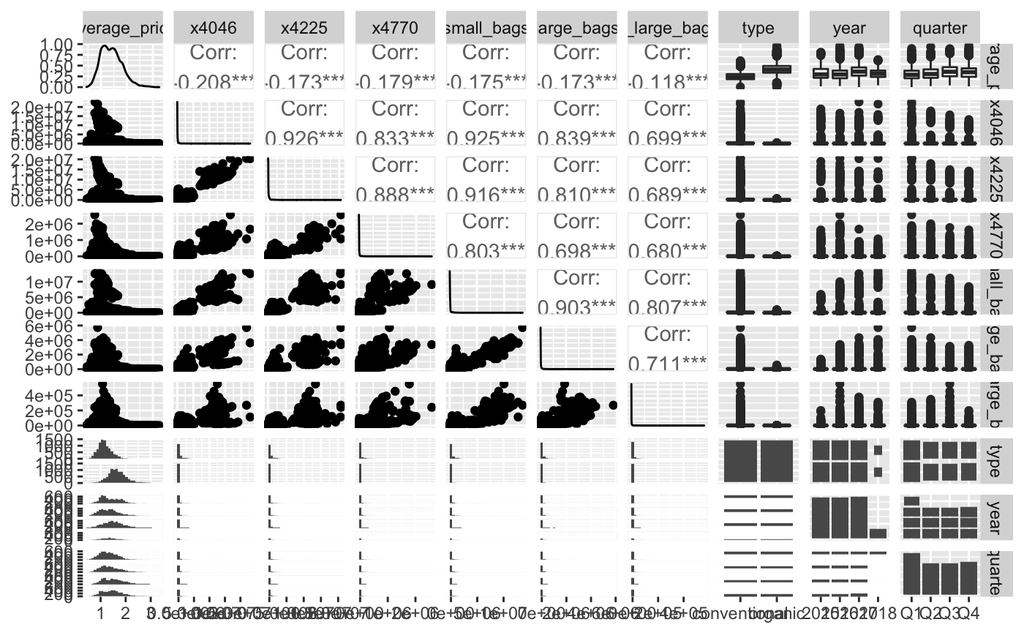

```r
avocados_trim %>%
  ggpairs(progress = FALSE)
```

EXPLANATORY MODEL WORK:

Use leaps package first

```r
regsubsets_exhaustive <- regsubsets(average_price ~ ., data = avocados_trim, nvmax = 8, method = "exhaustive")
```

```r
sum_regsubsets_exhaustive <- summary(regsubsets_exhaustive)
sum_regsubsets_exhaustive
```

```
Subset selection object
Call: regsubsets.formula(average_price ~ ., data = avocados_trim, nvmax = 8,
    method = "exhaustive")
13 Variables  (and intercept)
             Forced in Forced out
x4046            FALSE      FALSE
x4225            FALSE      FALSE
x4770            FALSE      FALSE
small_bags       FALSE      FALSE
large_bags       FALSE      FALSE
x_large_bags     FALSE      FALSE
typeorganic      FALSE      FALSE
year2016         FALSE      FALSE
year2017         FALSE      FALSE
year2018         FALSE      FALSE
quarterQ2        FALSE      FALSE
quarterQ3        FALSE      FALSE
quarterQ4        FALSE      FALSE
1 subsets of each size up to 8
Selection Algorithm: exhaustive
         x4046 x4225 x4770 small_bags large_bags x_large_bags typeorganic year2016 year2017 year2018 quarterQ2 quarterQ3
1  ( 1 ) " "   " "   " "   " "        " "        " "          "*"         " "      " "      " "      " "       " "
2  ( 1 ) " "   " "   " "   " "        " "        " "          "*"         " "      "*"      " "      " "       " "
3  ( 1 ) " "   " "   " "   " "        " "        " "          "*"         " "      "*"      " "      " "       "*"
4  ( 1 ) " "   " "   " "   " "        " "        " "          "*"         " "      "*"      " "      " "       "*"
5  ( 1 ) "*"   " "   " "   " "        " "        " "          "*"         " "      "*"      " "      " "       "*"
6  ( 1 ) "*"   "*"   " "   " "        " "        " "          "*"         " "      "*"      " "      " "       "*"
7  ( 1 ) "*"   "*"   " "   " "        " "        " "          "*"         " "      "*"      " "      "*"       "*"
8  ( 1 ) "*"   "*"   " "   " "        " "        " "          "*"         " "      "*"      "*"      "*"       "*"
         quarterQ4
1  ( 1 ) " "
2  ( 1 ) " "
3  ( 1 ) " "
4  ( 1 ) "*"
5  ( 1 ) "*"
6  ( 1 ) "*"
7  ( 1 ) "*"
8  ( 1 ) "*"
```

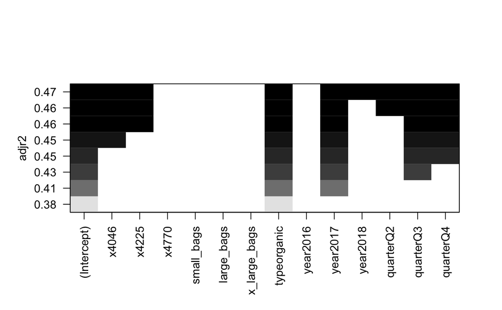

```r
plot(regsubsets_exhaustive, scale = "adjr2")
```

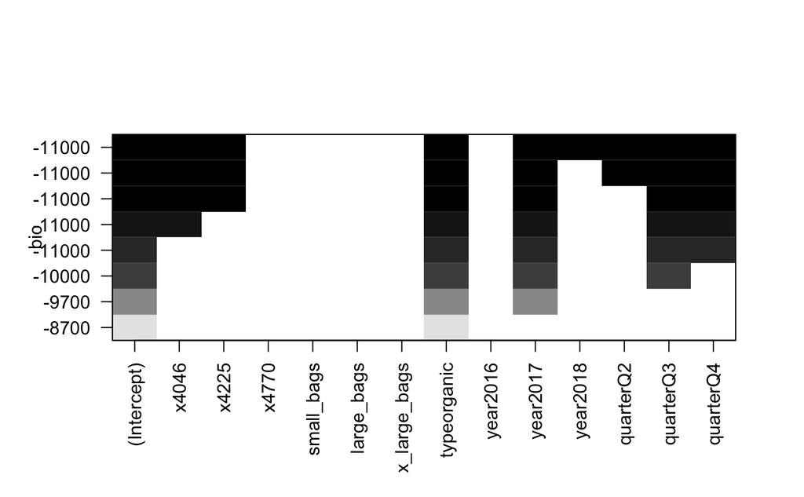

```r
plot(regsubsets_exhaustive, scale = "bic")
```

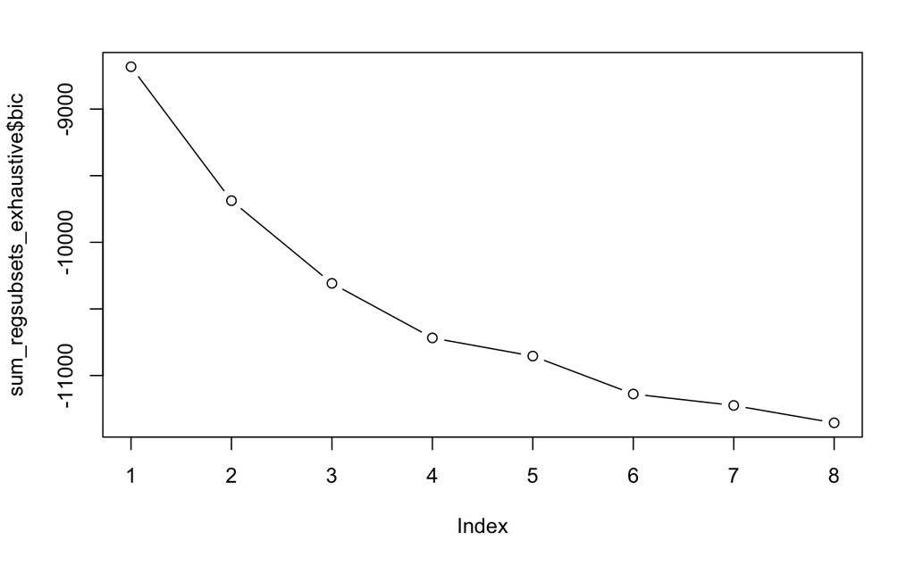

```r
plot(sum_regsubsets_exhaustive$bic, type = "b")
```

Now try with ggmulti

```r
glmulti_fit <- glmulti(
  average_price ~ .,
  data = avocados_trim,
  level = 2,
  minsize = 0,
  maxsize = -1,
  marginality = TRUE,
  method = "g",
  crit = bic,
  plotty = FALSE,
  report = TRUE,
  confsetsize = 100,
  fitfunction = lm
)
```

[output not shown]

[output cut: 557 more lines]

[output not shown]

```r
sum_glmulti_fit
```

```
$name
[1] "glmulti.analysis"

$method
[1] "g"

$fitting
[1] "lm"

$crit
[1] "bic"

$level
[1] 2

$marginality
[1] TRUE

$confsetsize
[1] 100

$bestic
[1] 5146.192

$icvalues
  [1] 5146.192 5146.738 5149.081 5149.867 5150.352 5151.052 5151.515 5153.046 5154.841 5155.986 5156.004 5156.004 5156.004
 [14] 5156.301 5156.823 5156.880 5157.652 5158.355 5158.614 5158.824 5159.527 5159.542 5159.597 5159.608 5164.206 5164.374
 [27] 5164.393 5165.815 5168.956 5169.906 5170.183 5170.319 5171.097 5171.671 5172.053 5173.350 5173.461 5173.918 5174.060
 [40] 5174.133 5174.198 5174.329 5174.553 5174.961 5175.364 5175.567 5176.414 5176.941 5178.153 5178.362 5181.058 5181.765
 [53] 5182.233 5183.482 5183.523 5184.159 5185.730 5185.845 5186.598 5187.725 5194.673 5198.900 5200.683 5205.965 5206.238
 [66] 5209.283 5213.004 5213.605 5214.675 5220.660 5223.410 5223.783 5227.321 5231.265 5233.034 5233.148 5234.555 5244.095
 [79] 5245.993 5256.114 5259.127 5268.807 5278.942 5292.258 5295.279 5295.407 5298.717 5300.050 5310.821 5328.055 5332.137
 [92] 5332.783 5333.004 5334.554 5335.353 5336.839 5339.352 5342.514 5344.461 5344.897

$bestmodel
[1] "average_price ~ 1 + year + quarter + x4046 + x4225 + small_bags + "
[2] "    large_bags + x_large_bags + type + quarter:year + x4225:x4046 + "
[3] "    small_bags:x4046 + small_bags:x4225 + large_bags:x4046 + "
[4] "    large_bags:small_bags + x_large_bags:x4046 + x_large_bags:large_bags + "
[5] "    type:x4046 + type:x4225 + type:large_bags + type:x_large_bags + "
```

[output cut: 9 more lines]

```
 [55] 3.076236e-09 2.237869e-09 1.020603e-09 9.634514e-10 6.610954e-10 3.762878e-10 1.166419e-11 1.408809e-12 5.778887e-13
 [64] 4.119627e-14 3.592671e-14 7.841489e-15 1.220068e-15 9.034223e-16 5.290398e-16 2.653094e-17 6.709372e-18 5.568725e-18
 [73] 9.491045e-19 1.320997e-19 5.456075e-20 5.154137e-20 2.549497e-20 2.162487e-22 8.374033e-23 5.309048e-25 1.176908e-25
 [82] 9.309712e-28 5.861673e-30 7.525071e-33 1.661381e-33 1.558883e-33 2.978961e-34 1.528955e-34 7.008926e-37 1.268739e-40
 [91] 1.647446e-41 1.192782e-41 1.068261e-41 4.922130e-42 3.300390e-42 1.569927e-42 4.469373e-43 9.194540e-44 3.473095e-44
[100] 2.793165e-44

$generations
[1] 1010

$elapsed
[1] 0.5001776

$includeobjects
[1] TRUE
```

```r
class(glmulti_fit)
```

```
[1] "glmulti"
attr(,"package")
[1] "glmulti"
```

```r
sum_glmulti_fit$bestmodel
```

```
[1] "average_price ~ 1 + year + quarter + x4046 + x4225 + small_bags + "
[2] "    large_bags + x_large_bags + type + quarter:year + x4225:x4046 + "
[3] "    small_bags:x4046 + small_bags:x4225 + large_bags:x4046 + "
[4] "    large_bags:small_bags + x_large_bags:x4046 + x_large_bags:large_bags + "
[5] "    type:x4046 + type:x4225 + type:large_bags + type:x_large_bags + "
[6] "    year:x4225 + year:small_bags + year:x_large_bags + year:type"
```

```r
glmulti_bestmodel
```

```
Call:
lm(formula = paste(sum_glmulti_fit$bestmodel, collapse = " "),
    data = avocados_trim)

Coefficients:
             (Intercept)                  year2016                  year2017                  year2018
               1.076e+00                -6.108e-02                 3.413e-02                 9.697e-02
               quarterQ2                 quarterQ3                 quarterQ4                     x4046
               1.627e-02                 7.185e-02                -2.331e-02                -1.398e-07
                   x4225                small_bags                large_bags              x_large_bags
               2.223e-08                 2.929e-07                -1.878e-07                -2.695e-06
             typeorganic        year2016:quarterQ2        year2017:quarterQ2        year2018:quarterQ2
               5.882e-01                -2.878e-02                 2.159e-01                        NA
      year2016:quarterQ3        year2017:quarterQ3        year2018:quarterQ3        year2016:quarterQ4
               1.115e-01                 3.045e-01                        NA                 2.779e-01
      year2017:quarterQ4        year2018:quarterQ4               x4046:x4225          x4046:small_bags
               2.578e-01                        NA                 9.033e-15                 1.268e-14
        x4225:small_bags          x4046:large_bags     small_bags:large_bags        x4046:x_large_bags
              -3.878e-14                -3.662e-14                 1.505e-13                 5.830e-13
 large_bags:x_large_bags         x4046:typeorganic         x4225:typeorganic    large_bags:typeorganic
              -3.382e-12                -4.380e-06                 3.257e-06                -3.735e-06
x_large_bags:typeorganic            year2016:x4225            year2017:x4225            year2018:x4225
               1.290e-03                 1.519e-07                 1.915e-07                 1.040e-07
     year2016:small_bags       year2017:small_bags       year2018:small_bags     year2016:x_large_bags
              -3.764e-07                -4.667e-07                -3.371e-07                 3.100e-06
   year2017:x_large_bags     year2018:x_large_bags      year2016:typeorganic      year2017:typeorganic
               4.828e-06                 2.665e-06                -1.309e-01                -1.579e-01
    year2018:typeorganic
              -1.984e-01
```

Interpretation: - Best model has an intercept of 1.076 and base values of year = 2015, type = conventional, and quarter = 1 - Predictors of year, type, quarter, small/large/x_large bag and x4046/x4225 - Lots of cross-terms: is this model overly complicated?